# Intro to R’s tidyverse for data science

# Setting up / loading packages

```r
knitr::opts_chunk$set(echo=TRUE,  message=FALSE, warning=FALSE)
```

```r
library(tidyverse)
library(tidymodels)
library(ggrepel)
```

# Reading files

```r
# Substitute this for the path where you keep your files
my_home <- "~/Google Drive/My Drive/extracurricular/Presentations/"

# State area measurements from https://www.census.gov/geographies/reference-files/2010/geo/state-area.html
# State abbreviations from https://about.usps.com/who-we-are/postal-history/state-abbreviations.htm
state_areas <- read_tsv(paste0(my_home, "state_areas.tsv"), col_names = TRUE, show_col_types = FALSE)
state_abbrev <- read_tsv(paste0(my_home, "state_abbreviations.tsv"), col_names = TRUE, show_col_types = FALSE)
```

# Using tidyverse packages to wrangle and display data

### 1. What does our data look like?

##### Check shape, display by a certain order, use specialized functions like `glimpse()`

```r
# check shape
dim(state_areas)
```

```
## [1] 57  7
```

```r
dim(state_abbrev)
```

```
## [1] 52  6
```

```r
# displaying
head(state_abbrev)
```

| Name | 1831 | 1874 | 1943 | 6/1963 | 10/1963_present |
| --- | --- | --- | --- | --- | --- |
| Alabama | Al. | Ala. | Ala. | ALA | AL |
| Alaska | -- | Alaska | Alaska | ALSK | AK |
| Arizona | -- | Ariz. | Ariz. | ARIZ | AZ |
| Arkansas | Ar. T. | Ark. | Ark. | ARK | AR |
| California | -- | Cal. | Calif. | CALIF | CA |
| Colorado | -- | Colo. | Colo. | COL | CO |

```r
# changing the order of the rows & displaying
state_areas %>% arrange(desc(Name)) %>% head()
```

| Name | Total_Sq_Mi | Total_Sq_Km | Land_Sq_Mi | Land_Sq_Km | Water_Total_Sq_Mi | Water_Total_Sq_Km |
| --- | --- | --- | --- | --- | --- | --- |
| Wyoming | 97813 | 253335 | 97093 | 251470 | 720 | 1864 |
| Wisconsin | 65496 | 169635 | 54158 | 140268 | 11339 | 29367 |
| West Virginia | 24230 | 62756 | 24038 | 62259 | 192 | 497 |
| Washington | 71298 | 184661 | 66456 | 172119 | 4842 | 12542 |
| Virginia | 42775 | 110787 | 39490 | 102279 | 3285 | 8508 |
| Vermont | 9616 | 24906 | 9217 | 23871 | 400 | 1035 |

```r
# glimpse is another way to see column types
glimpse(state_areas)
```

```
## Rows: 57
## Columns: 7
## $ Name              <chr> "United States", "Alabama", "Alaska", "Arizona", "Ar…
## $ Total_Sq_Mi       <dbl> 3796742, 52420, 665384, 113990, 53179, 163695, 10409…
## $ Total_Sq_Km       <dbl> 9833517, 135767, 1723337, 295234, 137732, 423967, 26…
## $ Land_Sq_Mi        <dbl> 3531905, 50645, 570641, 113594, 52035, 155779, 10364…
## $ Land_Sq_Km        <dbl> 9147593, 131171, 1477953, 294207, 134771, 403466, 26…
## $ Water_Total_Sq_Mi <dbl> 264837, 1775, 94743, 396, 1143, 7916, 452, 701, 540,…
## $ Water_Total_Sq_Km <dbl> 685924, 4597, 245383, 1026, 2961, 20501, 1170, 1816,…
```

##### Manipulate dataframe using `filter()`, `select()`, `rename()`; add the variables we want with `left_join()` and `mutate()`

```r
# we'll come up with a made-up category -- "dry" or "water" states
# based on the total water area / total area
states_pct_water <- state_areas %>%
  filter((Name != "United States") & (Name != "District of Columbia")) %>%
  select(Name, ends_with("Mi")) %>% # keep the area data in miles
  mutate(pct_water = 100 * (Water_Total_Sq_Mi / Total_Sq_Mi),
         category = ifelse(as.numeric(pct_water) > 20, "water state", "dry state"))
```

```r
# cleaning up the abbreviations dataframe, renaming the column we're interested in (present abbreviation)
state_abbrev <- state_abbrev %>%
  select(Name, ends_with("present")) %>%
  rename(abbreviation = ends_with("present")) %>% #new name = old name
  mutate(abbreviation = str_sub(abbreviation,1,2)) #make sure abbreviation is two letters
```

```r
# joining to our water table
states_pct_water <- left_join(states_pct_water, state_abbrev, by = "Name")
head(states_pct_water)
```

| Name | Total_Sq_Mi | Land_Sq_Mi | Water_Total_Sq_Mi | pct_water | category | abbreviation |
| --- | --- | --- | --- | --- | --- | --- |
| Alabama | 52420 | 50645 | 1775 | 3.3861122 | dry state | AL |
| Alaska | 665384 | 570641 | 94743 | 14.2388455 | dry state | AK |
| Arizona | 113990 | 113594 | 396 | 0.3473989 | dry state | AZ |
| Arkansas | 53179 | 52035 | 1143 | 2.1493447 | dry state | AR |
| California | 163695 | 155779 | 7916 | 4.8358227 | dry state | CA |
| Colorado | 104094 | 103642 | 452 | 0.4342229 | dry state | CO |

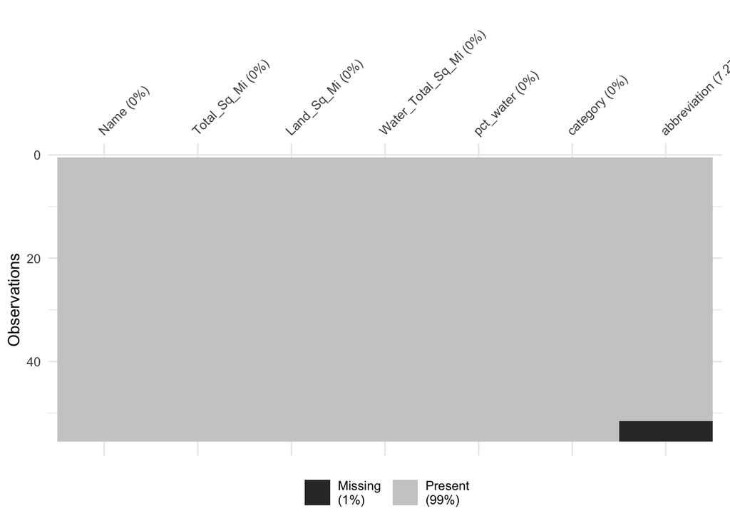

```r
# see how our percentage calculation & join went -- any NA's or join by wrong key?
library(naniar)
vis_miss(states_pct_water)
```

```r
# in addition to glimpse, another method from outside the tidyverse is skim
library(skimr)
skim(states_pct_water)
```

Data summary

| Name | states_pct_water |
| --- | --- |
| Number of rows | 55 |
| Number of columns | 7 |
| _______________________ |  |
| Column type frequency: |  |
| character | 3 |
| numeric | 4 |
| ________________________ |  |
| Group variables | None |

**Variable type: character**

| skim_variable | n_missing | complete_rate | min | max | empty | n_unique | whitespace |
| --- | --- | --- | --- | --- | --- | --- | --- |
| Name | 0 | 1.00 | 4 | 24 | 0 | 55 | 0 |
| category | 0 | 1.00 | 9 | 11 | 0 | 2 | 0 |
| abbreviation | 4 | 0.93 | 2 | 2 | 0 | 51 | 0 |

**Variable type: numeric**

| skim_variable | n_missing | complete_rate | mean | sd | p0 | p25 | p50 | p75 | p100 | hist |
| --- | --- | --- | --- | --- | --- | --- | --- | --- | --- | --- |
| Total_Sq_Mi | 0 | 1 | 69197.49 | 95173.42 | 571.00 | 18318.00 | 53819.00 | 82923.5 | 665384.00 | ▇▁▁▁▁ |
| Land_Sq_Mi | 0 | 1 | 64288.58 | 84220.46 | 76.00 | 16872.50 | 50645.00 | 78225.5 | 570641.00 | ▇▁▁▁▁ |
| Water_Total_Sq_Mi | 0 | 1 | 4908.96 | 13637.82 | 192.00 | 596.00 | 1494.00 | 3625.0 | 94743.00 | ▇▁▁▁▁ |
| pct_water | 0 | 1 | 14.09 | 21.70 | 0.24 | 1.78 | 4.16 | 16.5 | 90.74 | ▇▁▁▁▁ |

```r
# exclude entries that do not have a matching abbreviation
states_pct_water <- filter(states_pct_water, !is.na(abbreviation))
head(states_pct_water)
```

| Name | Total_Sq_Mi | Land_Sq_Mi | Water_Total_Sq_Mi | pct_water | category | abbreviation |
| --- | --- | --- | --- | --- | --- | --- |
| Alabama | 52420 | 50645 | 1775 | 3.3861122 | dry state | AL |
| Alaska | 665384 | 570641 | 94743 | 14.2388455 | dry state | AK |
| Arizona | 113990 | 113594 | 396 | 0.3473989 | dry state | AZ |
| Arkansas | 53179 | 52035 | 1143 | 2.1493447 | dry state | AR |
| California | 163695 | 155779 | 7916 | 4.8358227 | dry state | CA |
| Colorado | 104094 | 103642 | 452 | 0.4342229 | dry state | CO |

### 2. Plotting associations between variables

##### Starting to ask more pointed questions of our data, use `group_by()` and `summarize()` to get summary statistics

```r
# grouping and summarizing
states_category_mean_area <- states_pct_water %>%
  group_by(category) %>%
  summarize(mean_total_area = mean(Total_Sq_Mi))

states_category_mean_area
```

| category | mean_total_area |
| --- | --- |
| dry state | 83228.09 |
| water state | 19995.00 |

##### Changing the shape of our dataframes with `pivot_longer()` and `pivot_wider()` (formerly `spread()` and `gather()`)

```r
# pivot_longer (formerly "gather")
# this lets us work with the legend of different types of areas more easily
states_pct_water_long <- states_pct_water %>%
  pivot_longer(cols = ends_with("Mi"), names_to = "area_type", values_to = "area_sq_mi")
head(states_pct_water_long)
```

| Name | pct_water | category | abbreviation | area_type | area_sq_mi |
| --- | --- | --- | --- | --- | --- |
| Alabama | 3.386112 | dry state | AL | Total_Sq_Mi | 52420 |
| Alabama | 3.386112 | dry state | AL | Land_Sq_Mi | 50645 |
| Alabama | 3.386112 | dry state | AL | Water_Total_Sq_Mi | 1775 |
| Alaska | 14.238846 | dry state | AK | Total_Sq_Mi | 665384 |
| Alaska | 14.238846 | dry state | AK | Land_Sq_Mi | 570641 |
| Alaska | 14.238846 | dry state | AK | Water_Total_Sq_Mi | 94743 |

##### A sampling of what we can visualize with `ggplot2`

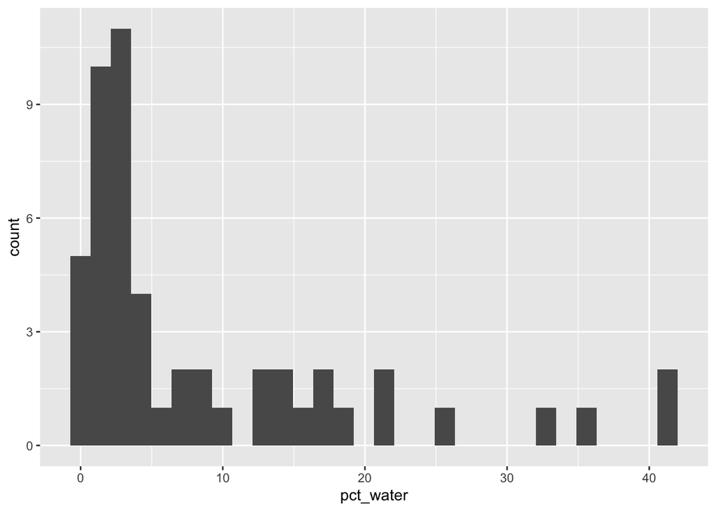

```r
# A simple histogram of our made-up metric, "pct_water"
ggplot(data = states_pct_water) +
  geom_histogram(mapping = aes(x = pct_water))
```

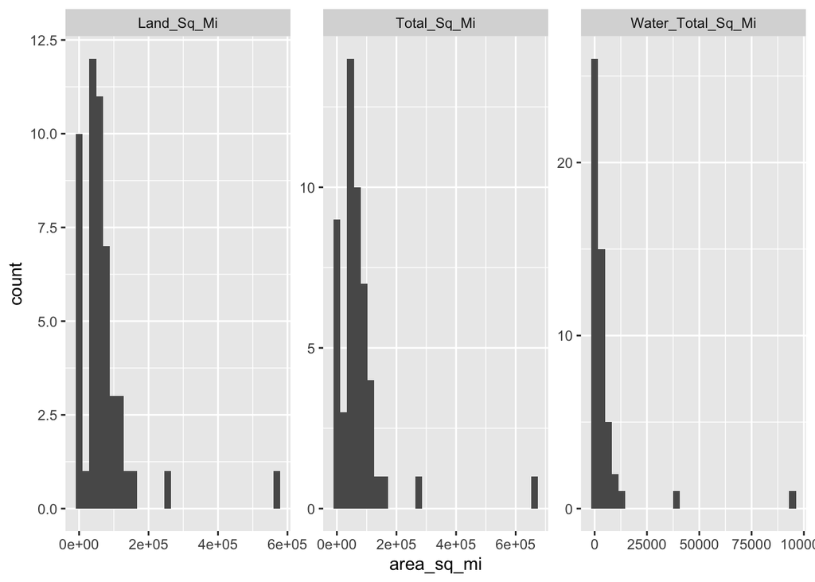

```r
# what is the overall distribution of areas? differentiate by water/land
# facet_wrap -- somewhat independent plots by category
ggplot(data = states_pct_water_long, mapping = aes(x = area_sq_mi)) +
  geom_histogram() +
  facet_wrap(~area_type, scales = "free")
```

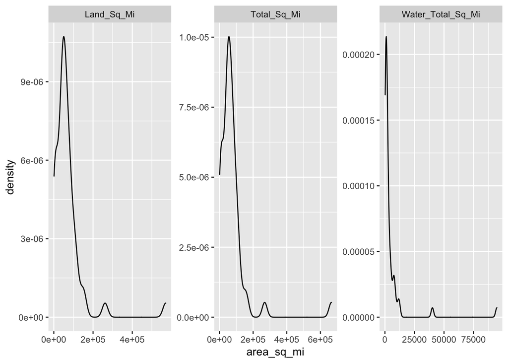

```r
ggplot(data = states_pct_water_long, mapping = aes(x = area_sq_mi)) +
  geom_density() +
  facet_wrap(~area_type, scales = "free")
```

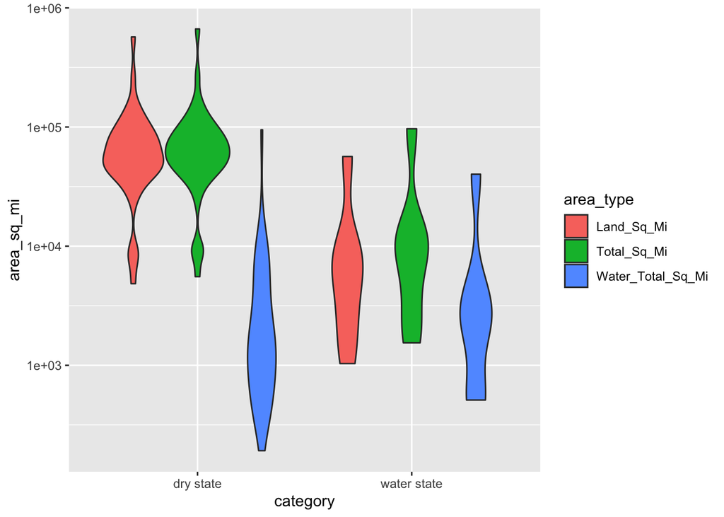

```r
# do our made up "dry states" have less water after all?
# plot together but split by "fill" as opposed to facet_wrap; can't set independent axes in this
ggplot(data = states_pct_water_long, mapping = aes(x = category, y = area_sq_mi, fill = area_type)) +
  geom_violin() +
  scale_y_log10()
```

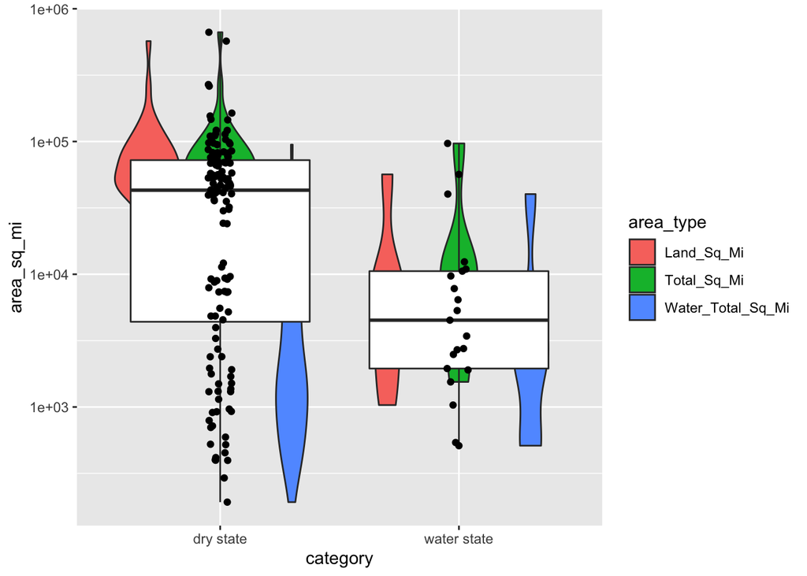

```r
ggplot(data = states_pct_water_long, mapping = aes(x = category, y = area_sq_mi)) +
  geom_violin(mapping = aes(fill = area_type)) +
  geom_boxplot() + # because the fill is not inherited from ggplot() call, boxplots are of overall areas
  geom_jitter(width = 0.05) +
  scale_y_log10()
```

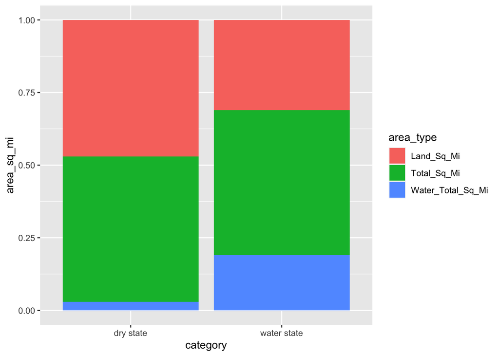

```r
ggplot(data = states_pct_water_long) +
  geom_bar(mapping = aes(x = category, y = area_sq_mi, fill = area_type),
           position = "fill", stat = "identity")
```

### 3. Customizing plots

##### Is our metric of %water biased by small, coastal/island states? A simple scatterplot

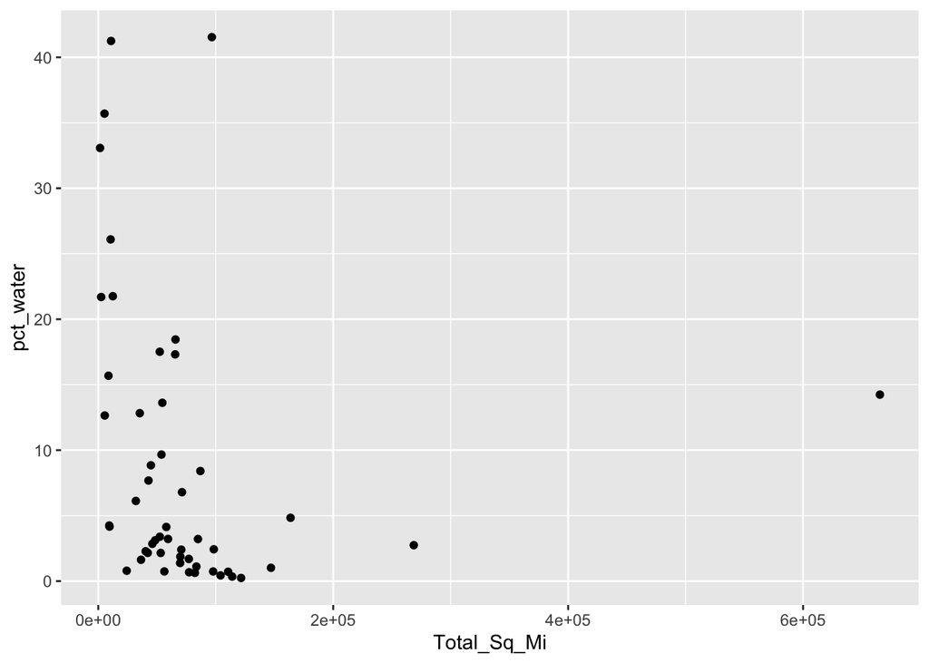

```r
sp <- ggplot(states_pct_water) +
  geom_point(mapping = aes(x = Total_Sq_Mi, y = pct_water))
sp
```

##### Custom scaling, adding titles

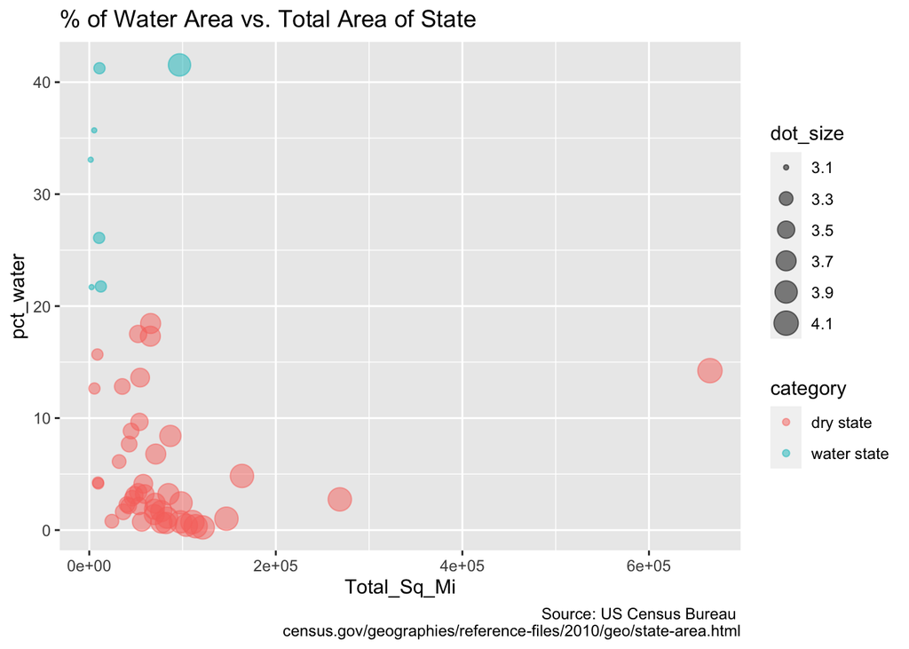

```r
# adding a scale to the dots
get_closest_quantile <- function(my_state_area){
  # generate quantiles by 10%
  q <- quantile(states_pct_water$Total_Sq_Mi, probs = seq(0,1,by=0.1))
  # get the index of the closest quantile to my specific state area
  q_idx <- which.min(abs(q - my_state_area))
  # return a number 1-10 (divided by 10 to make a decimal)
  return(q_idx/10)
}

# some baseline dot size + an added scaling factor according to the closest percentile
states_pct_water <- states_pct_water %>%
  mutate(dot_size = 3 + as.numeric(unlist(lapply(Total_Sq_Mi, get_closest_quantile))))

# add title, caption
# in addition to sizing by our new scale, add transparency (alpha)
sp <- ggplot(states_pct_water, aes(x = Total_Sq_Mi, y = pct_water)) +
  geom_point(mapping = aes(color = category, size = dot_size), alpha = 0.5) +
  labs(title = "% of Water Area vs. Total Area of State",
       caption = "Source: US Census Bureau \n census.gov/geographies/reference-files/2010/geo/state-area.html")

sp
```

##### Adding a custom theme, more layers with labels

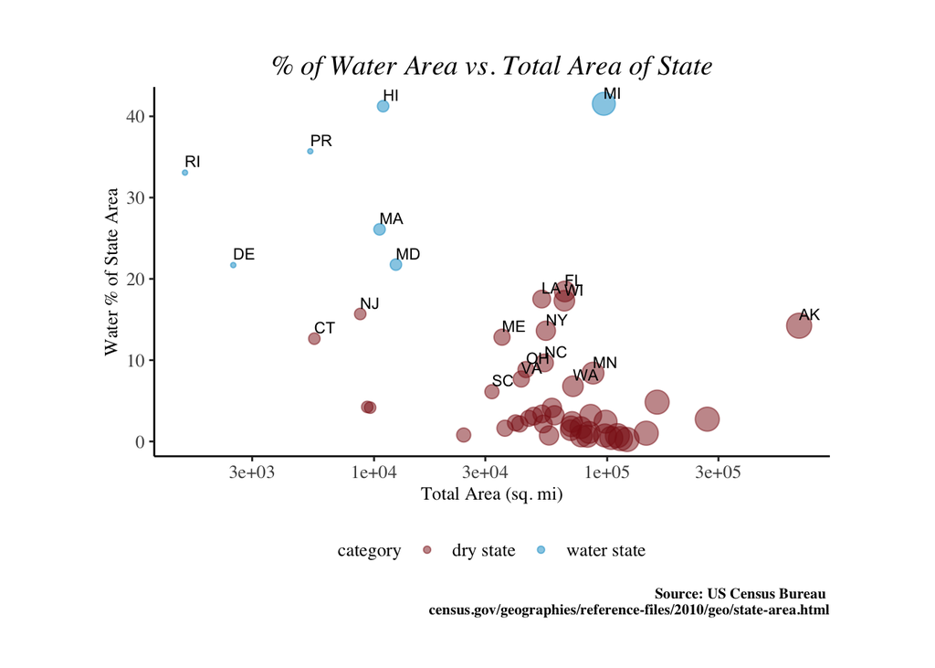

```r
clean_theme <- theme_classic() + # layer our modifications on top of a default ggplot theme
  theme(plot.title = element_text(family = "serif", size = 15, face = 'italic',  hjust = 0.5, vjust = 0.5),
        plot.caption = element_text(family = "serif", size = 8, face = 'bold', hjust = 1, vjust = 0.5),
        axis.title = element_text(family = "serif", size = 10),
        axis.text = element_text(family = "serif", size = 10),
        axis.text.x = element_text(family = "serif", size = 10),
        legend.title = element_text(family = "serif", size = 10),
        legend.text = element_text(family = "serif", size = 10),
        legend.position = "bottom",
        plot.margin = margin(1,2,1,2, "cm")) # top, right, bottom, left margins

sp <- sp +
  scale_color_manual(values = c("firebrick4", "deepskyblue3")) + # adjust the color legend
  scale_size(guide="none") + # hide the size legend
  xlab("Total Area (sq. mi)") +
  ylab("Water % of State Area") +
  scale_x_log10() +
  clean_theme

sp +
  geom_text(data = filter(states_pct_water, pct_water > 5), #subsetting to avoid crowding
            mapping = aes(label = abbreviation), hjust = 0, vjust = -0.5, size = 3)
```

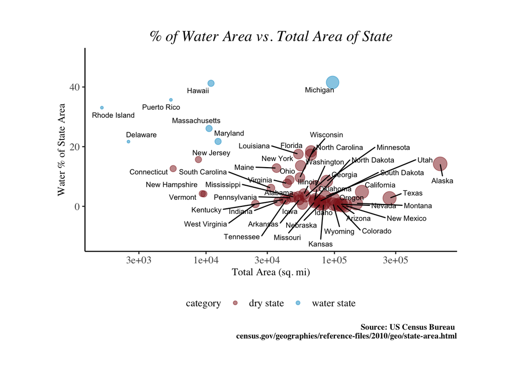

```r
# alternative to geom_text, ggrepel deals with crowding labels
sp +
  ylim(-12,50) +
  geom_text_repel(mapping = aes(label = Name),
                  size = 2.5, max.overlaps = 50, force_pull = 0.01)
```

# Statistics with tidymodels, other tidyverse extensions

### Overview of a second, independent dataset– this time using `skim()`

```r
# we'll bring in one of the default R datasets -- us_rent_income; see data()
skim(us_rent_income)
```

Data summary

| Name | us_rent_income |
| --- | --- |
| Number of rows | 104 |
| Number of columns | 5 |
| _______________________ |  |
| Column type frequency: |  |
| character | 3 |
| numeric | 2 |
| ________________________ |  |
| Group variables | None |

**Variable type: character**

| skim_variable | n_missing | complete_rate | min | max | empty | n_unique | whitespace |
| --- | --- | --- | --- | --- | --- | --- | --- |
| GEOID | 0 | 1 | 2 | 2 | 0 | 52 | 0 |
| NAME | 0 | 1 | 4 | 20 | 0 | 52 | 0 |
| variable | 0 | 1 | 4 | 6 | 0 | 2 | 0 |

**Variable type: numeric**

| skim_variable | n_missing | complete_rate | mean | sd | p0 | p25 | p50 | p75 | p100 | hist |
| --- | --- | --- | --- | --- | --- | --- | --- | --- | --- | --- |
| estimate | 1 | 0.99 | 14923.08 | 14459.89 | 464 | 864.5 | 1507 | 28872.0 | 43198 | ▇▁▂▆▁ |
| moe | 1 | 0.99 | 95.50 | 119.74 | 2 | 4.5 | 18 | 153.5 | 681 | ▇▃▁▁▁ |

### How well do the new variables correlate with our land/water area data?

```r
# merge our state water data with rent/income data
all_state_data <- us_rent_income %>%
  rename(Name = NAME) %>%
  select(-moe, -GEOID) %>%
  pivot_wider(names_from = variable, values_from = estimate) %>%
  left_join(states_pct_water, by = "Name") %>%
  na.omit()

head(all_state_data)
```

| Name | income | rent | Total_Sq_Mi | Land_Sq_Mi | Water_Total_Sq_Mi | pct_water | category | abbreviation | dot_size |
| --- | --- | --- | --- | --- | --- | --- | --- | --- | --- |
| Alabama | 24476 | 747 | 52420 | 50645 | 1775 | 3.3861122 | dry state | AL | 3.5 |
| Alaska | 32940 | 1200 | 665384 | 570641 | 94743 | 14.2388455 | dry state | AK | 4.1 |
| Arizona | 27517 | 972 | 113990 | 113594 | 396 | 0.3473989 | dry state | AZ | 4.0 |
| Arkansas | 23789 | 709 | 53179 | 52035 | 1143 | 2.1493447 | dry state | AR | 3.5 |
| California | 29454 | 1358 | 163695 | 155779 | 7916 | 4.8358227 | dry state | CA | 4.0 |
| Colorado | 32401 | 1125 | 104094 | 103642 | 452 | 0.4342229 | dry state | CO | 3.9 |

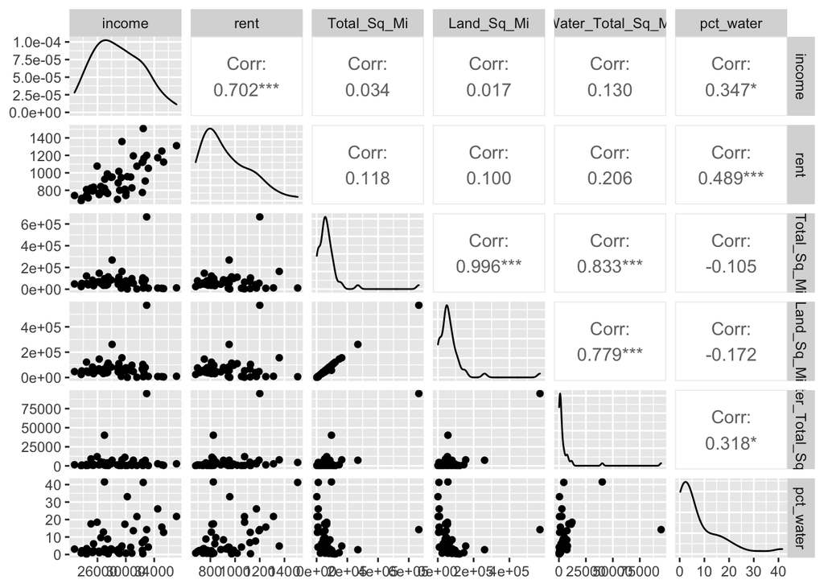

```r
library(GGally)
# can also get nice plots using ggpairs
all_num_state_data <- all_state_data %>% select(-dot_size) %>% select_if(is.double)
ggpairs(all_num_state_data)
```

```r
library(corrr)
# can easily get correlation tables and plots using corrr from tidymodels
all_num_state_data_cor <- all_num_state_data %>% correlate() %>% rearrange() %>% shave()

fashion(all_num_state_data_cor) # text display in a nice format
```

| term | pct_water | income | rent | Water_Total_Sq_Mi | Total_Sq_Mi | Land_Sq_Mi |
| --- | --- | --- | --- | --- | --- | --- |
| pct_water |  |  |  |  |  |  |
| income | .35 |  |  |  |  |  |
| rent | .49 | .70 |  |  |  |  |
| Water_Total_Sq_Mi | .32 | .13 | .21 |  |  |  |
| Total_Sq_Mi | -.11 | .03 | .12 | .83 |  |  |
| Land_Sq_Mi | -.17 | .02 | .10 | .78 | 1.00 |  |

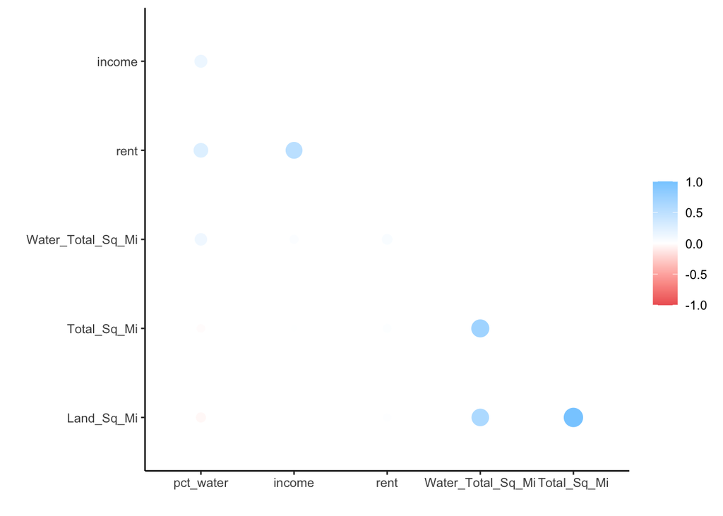

```r
rplot(all_num_state_data_cor) # circle plot with correlation magnitude
```

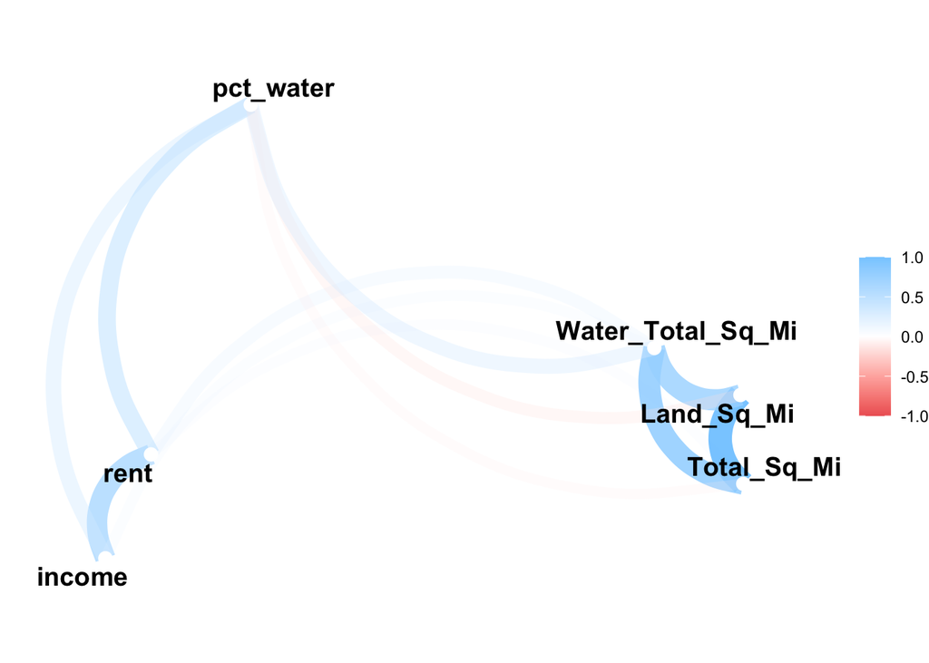

```r
# can also make other fancier correlation plots
all_num_state_data %>%
  correlate() %>%
  network_plot(min_cor = .1)
```

- unsurprisingly, rent/income are correlated to each other; land/total square miles are in turn correlated to each other
  - i.e. our two separate datasets have (mostly) nothing to do with each other
- pct_water seems to be behaving weirdly: correlates better with rent than with total water sq. miles
- we can use our somewhat orthogonal variables to reduce dimensions using PCA– see which states are more similar to each other
  - we expect PC1 and PC2 to reflect rent/income and land or water area (respectively); and in turn we expect pct_water to not explain much
  - can check this hypothesis from the loadings

### What principal components explain differences between states?

##### Run PCA

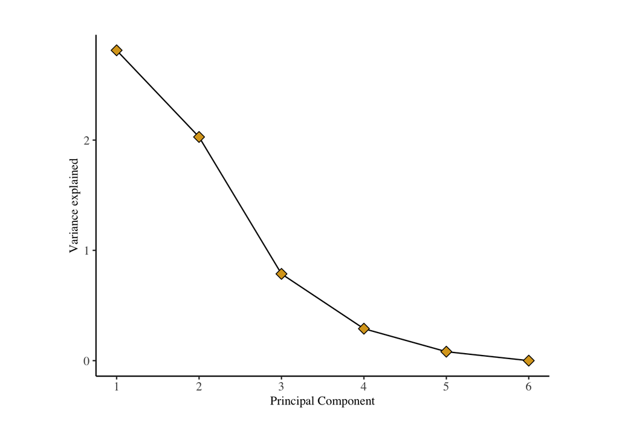

```r
# first make a matrix with states as row names
states_mat <- as.data.frame(all_num_state_data)
rownames(states_mat) <- all_state_data$Name

# run PCA
states_pca <- prcomp(states_mat, center = TRUE, scale = TRUE)

# what is the variance explained by each PC? individual + cumulative
states_pca_var <- data.frame(
  PC = seq(1, length(states_pca$sdev)),
  stdev = states_pca$sdev,
  var = (states_pca$sdev)^2,
  var_pct = cumsum((states_pca$sdev)^2 / sum((states_pca$sdev)^2))
)

ggplot(states_pca_var) +
  geom_line(mapping = aes(x = PC, y = var)) +
  geom_point(mapping = aes(x = PC, y = var), size = 3, shape = 23, fill = "goldenrod") +
  scale_x_continuous(labels = min(states_pca_var$PC):max(states_pca_var$PC),
                     breaks = min(states_pca_var$PC):max(states_pca_var$PC)) +
  xlab("Principal Component") +
  ylab("Variance explained") +
  clean_theme
```

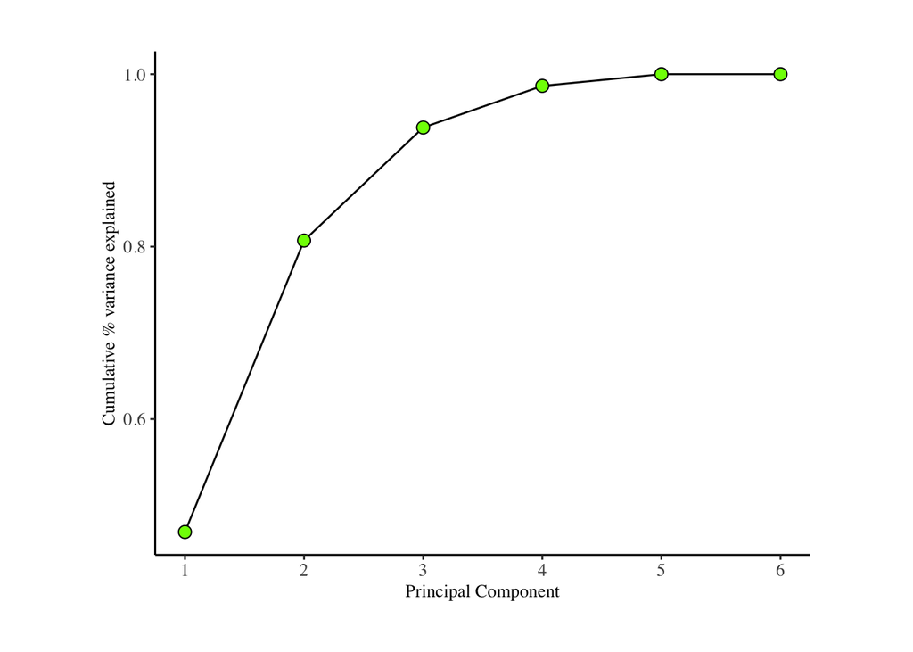

```r
ggplot(states_pca_var) +
  geom_line(mapping = aes(x = PC, y = var_pct)) +
  geom_point(mapping = aes(x = PC, y = var_pct), size = 3, shape = 21, fill = "lawngreen") +
  scale_x_continuous(labels = min(states_pca_var$PC):max(states_pca_var$PC),
                     breaks = min(states_pca_var$PC):max(states_pca_var$PC)) +
  xlab("Principal Component") +
  ylab("Cumulative % variance explained") +
  clean_theme
```

##### Examine principal components and loadings

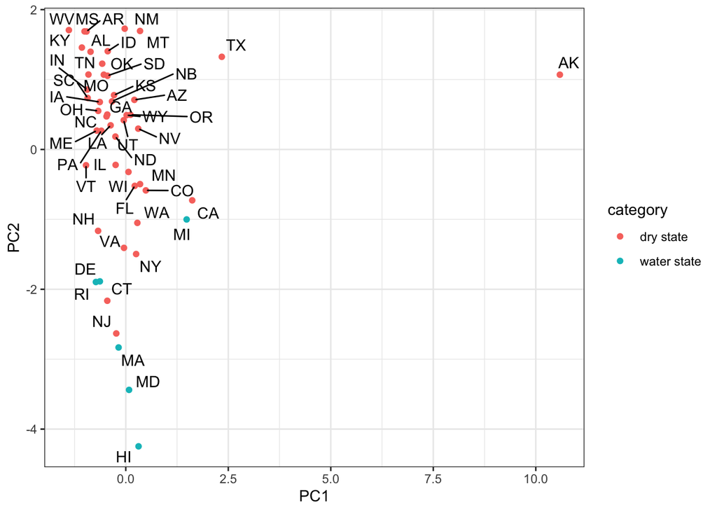

```r
states_pca_df <- as.data.frame(states_pca$x) %>%
  mutate(Name = rownames(states_mat)) %>%
  select(Name, PC1, PC2) %>%
  left_join(states_pct_water, by = "Name")

ggplot(states_pca_df, mapping = aes(x = PC1, y = PC2)) +
  geom_point(mapping = aes(color = category)) +
  geom_text_repel(mapping = aes(label = abbreviation), max.overlaps = 50) +
  theme_bw()
```

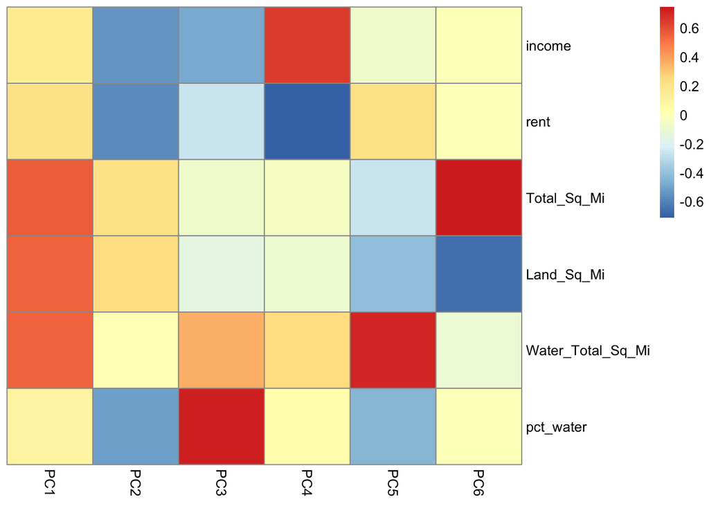

```r
library(pheatmap)
# pheatmap is another quick way to visualize your numerical tables
pheatmap(states_pca$rotation, cluster_cols = FALSE, cluster_rows = FALSE)
```

#### K-means clustering (code adapted from https://www.tidymodels.org/learn/statistics/k-means/)

```r
state_data_pca_mat <- states_pca_df %>% select(PC1, PC2)
rownames(state_data_pca_mat) <- states_pca_df$Name

state_data_kclust2 <- kmeans(state_data_pca_mat, centers = 2)
summary(state_data_kclust2)
```

```
##              Length Class  Mode
## cluster      50     -none- numeric
## centers       4     -none- numeric
## totss         1     -none- numeric
## withinss      2     -none- numeric
## tot.withinss  1     -none- numeric
## betweenss     1     -none- numeric
## size          2     -none- numeric
## iter          1     -none- numeric
## ifault        1     -none- numeric
```

```r
state_data_kclust2_aug <- augment(state_data_kclust2, state_data_pca_mat)
state_data_kclust2_aug
```

| .rownames | PC1 | PC2 | .cluster |
| --- | --- | --- | --- |
| Alabama | -0.85936776 | 1.3972824 | 2 |
| Alaska | 10.58763169 | 1.0691309 | 1 |
| Arizona | 0.20926137 | 0.7091348 | 2 |
| Arkansas | -0.95674635 | 1.6873602 | 2 |
| California | 1.62043847 | -0.7278199 | 1 |
| Colorado | 0.48883708 | -0.5854988 | 1 |
| Connecticut | -0.45111277 | -2.1643502 | 1 |
| Delaware | -0.63242788 | -1.8869271 | 1 |
| Florida | 0.21884305 | -0.5208706 | 1 |
| Georgia | -0.45197051 | 0.4993238 | 2 |

[output cut: 40 more lines]

```r
state_data_kclust2_aug$.cluster
```

```
##        Alabama         Alaska        Arizona       Arkansas     California
##              2              1              2              2              1
##       Colorado    Connecticut       Delaware        Florida        Georgia
##              1              1              1              1              2
##         Hawaii          Idaho       Illinois        Indiana           Iowa
##              1              2              2              2              2
##         Kansas       Kentucky      Louisiana          Maine       Maryland
##              2              2              2              2              1
##  Massachusetts       Michigan      Minnesota    Mississippi       Missouri
##              1              1              1              2              2
##        Montana       Nebraska         Nevada  New Hampshire     New Jersey
##              2              2              2              1              1
##     New Mexico       New York North Carolina   North Dakota           Ohio
##              2              1              2              2              2
##       Oklahoma         Oregon   Pennsylvania   Rhode Island South Carolina
##              2              2              2              1              2
##   South Dakota      Tennessee          Texas           Utah        Vermont
##              2              2              2              2              2
##       Virginia     Washington  West Virginia      Wisconsin        Wyoming
##              1              1              2              2              2
## Levels: 1 2
```

```r
# not incredibly informative, let's try iterating through possible values of k
state_data_kclust_iter <-
  tibble(k = 1:6) %>%
  mutate(
    kclust = map(k, ~kmeans(state_data_pca_mat, .x)),
    tidied = map(kclust, tidy), # turn into a tibble
    glanced = map(kclust, glance), # summary "glance"
    augmented = map(kclust, augment, state_data_pca_mat) # augment our original data with k-means clusters
  )
# we have lists of tibbles, each corresponding to a k
state_data_kclust_iter
```

| k | kclust | tidied | glanced | augmented |
| --- | --- | --- | --- | --- |
| 1 |  |  |  |  |
| 2 |  |  |  |  |
| 3 |  |  |  |  |
| 4 |  |  |  |  |
| 5 |  |  |  |  |
| 6 |  |  |  |  |

```r
# the augmented list contains the data we want, again-- one tibble per value of k
state_data_kclust_iter$augmented
```

```
## [[1]]
## # A tibble: 50 × 4
##    .rownames      PC1    PC2 .cluster
##    <chr>        <dbl>  <dbl> <fct>
##  1 Alabama     -0.859  1.40  1
##  2 Alaska      10.6    1.07  1
##  3 Arizona      0.209  0.709 1
##  4 Arkansas    -0.957  1.69  1
##  5 California   1.62  -0.728 1
##  6 Colorado     0.489 -0.585 1
##  7 Connecticut -0.451 -2.16  1
##  8 Delaware    -0.632 -1.89  1
##  9 Florida      0.219 -0.521 1
## 10 Georgia     -0.452  0.499 1
## # … with 40 more rows
##
## [[2]]
## # A tibble: 50 × 4
##    .rownames      PC1    PC2 .cluster
##    <chr>        <dbl>  <dbl> <fct>
##  1 Alabama     -0.859  1.40  2
##  2 Alaska      10.6    1.07  1
##  3 Arizona      0.209  0.709 2
##  4 Arkansas    -0.957  1.69  2
##  5 California   1.62  -0.728 1
##  6 Colorado     0.489 -0.585 1
##  7 Connecticut -0.451 -2.16  1
##  8 Delaware    -0.632 -1.89  1
##  9 Florida      0.219 -0.521 1
## 10 Georgia     -0.452  0.499 2
## # … with 40 more rows
##
## [[3]]
## # A tibble: 50 × 4
##    .rownames      PC1    PC2 .cluster
##    <chr>        <dbl>  <dbl> <fct>
##  1 Alabama     -0.859  1.40  3
##  2 Alaska      10.6    1.07  1
##  3 Arizona      0.209  0.709 3
##  4 Arkansas    -0.957  1.69  3
```

[output cut: 40 more lines]

```
## [[6]]
## # A tibble: 50 × 4
##    .rownames      PC1    PC2 .cluster
##    <chr>        <dbl>  <dbl> <fct>
##  1 Alabama     -0.859  1.40  6
##  2 Alaska      10.6    1.07  4
##  3 Arizona      0.209  0.709 5
##  4 Arkansas    -0.957  1.69  6
##  5 California   1.62  -0.728 3
##  6 Colorado     0.489 -0.585 3
##  7 Connecticut -0.451 -2.16  2
##  8 Delaware    -0.632 -1.89  2
##  9 Florida      0.219 -0.521 3
## 10 Georgia     -0.452  0.499 5
## # … with 40 more rows
```

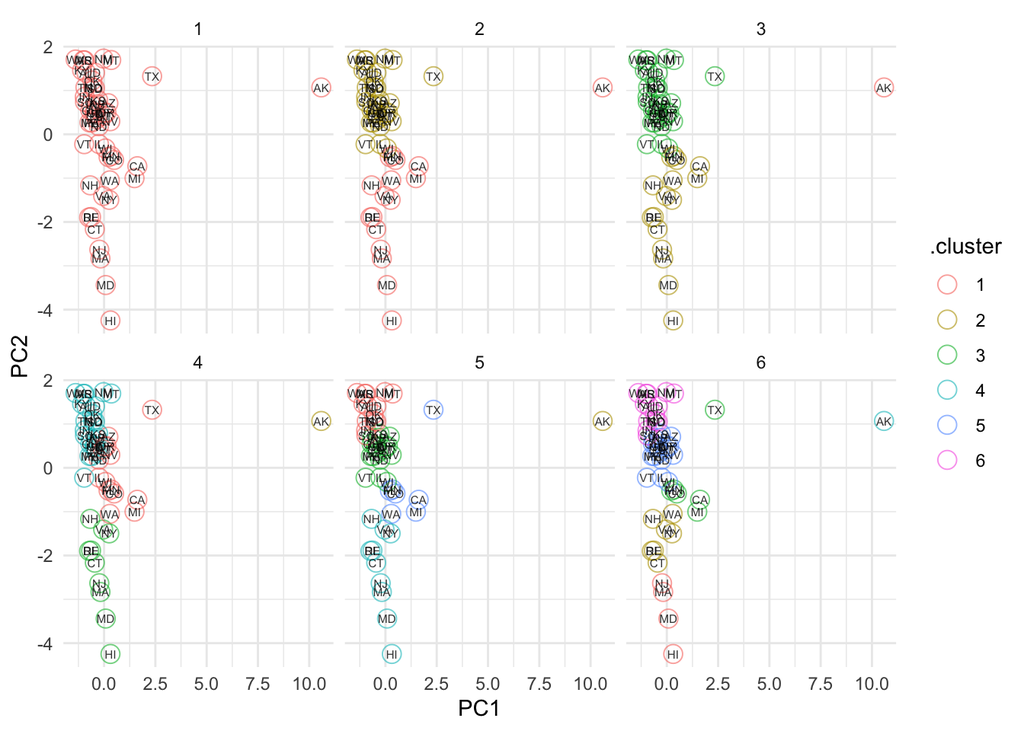

```r
# now plot each tibble per k, with PC1 and PC2 as the coordinates
state_data_kclust_iter_df <- unnest(state_data_kclust_iter, cols = c(augmented))
state_data_kclust_iter_df$.rownames <- state_abbrev$abbreviation[match(state_data_kclust_iter_df$.rownames, state_abbrev$Name)]

ggplot(data = state_data_kclust_iter_df,
       mapping = aes(x = PC1, y = PC2)) +
  geom_point(mapping = aes(color = .cluster), alpha = 0.6, size = 4, shape = 21) +
  geom_text(mapping = aes(label = .rownames), alpha = 0.8, size = 2) +
  facet_wrap(~k) + theme_minimal()
```

```r
save.image(file = paste0(my_home, "R_tidyverse_data_science.RData"))
```